# CAN7035 ML/AL Assignment LAQ2

Use limma to find significant genes based on differential expression

```r
library(limma)
# Create an empty list to store the results when accessing all 4 clusters
top_20_genes_list <- list()
all_genes_list <- list()

# Create a loop to go through all 4 clusters
for (k in 1:4) {

# Define group and compare one cluster to the rest
  # this creates a temporary label for the 90 samples i.e. the current sample is labeled as ClusterK           if not labeled as Other
  group <- factor(ifelse(cluster_memberships == k, "ClusterK", "Other"))

  # Design matrix. Only calculate the mean expression for ClusterK and Other independently
  mod <- model.matrix(~0 + group)
  # Rename the columns of the matrix
  colnames(mod) <- c("ClusterK", "Other")
  # Align correct sample names to the rows of the design matrix correctly
  rownames(mod) <- colnames(escc_exp)

  # Fit a linear model for all 1500 genes
  fit <- lmFit(escc_exp, mod)
  # Contrast - Subtract the average of Other from the average of ClusterK
  con.matrix <- makeContrasts(ClusterKvsOther = ClusterK - Other, levels = mod)
  # Apply contrast to the linear model
  fit2 <- contrasts.fit(fit, con.matrix)
  fit2 <- eBayes(fit2)

  # Top 20 DE genes
  top20 <- topTable(fit2, adjust = "BH", number = 20, sort.by = "logFC")
  top_20_genes_list[[k]] <- top20

  # All DE genes for GSEA
  all_genes <- topTable(fit2, adjust = "BH", number = Inf)
  all_genes_list <- append(all_genes_list, list(all_genes))

  cat("\n=== Top 20 DE Genes for Cluster", k, "vs all others ===\n")
  print(top20)
}
```

```
##
## === Top 20 DE Genes for Cluster 1 vs all others ===
##             logFC   AveExpr         t      P.Value    adj.P.Val           B
## ALDH1A1 -3.491402  3.931921 -8.639947 1.188790e-13 8.915926e-11 20.66112226
## NTS     -3.390195  3.114868 -5.034762 2.220077e-06 3.083440e-05  4.53191473
## KRT14    3.246256 10.444821  7.463869 3.709274e-11 9.273185e-09 15.10997700
## KRT4    -2.914583  3.610393 -3.690245 3.707560e-04 1.754366e-03 -0.29904611
## ALDH3A1 -2.847972  4.829094 -4.946090 3.197093e-06 4.029949e-05  4.18437169
## ADH7    -2.814785  4.082487 -5.579560 2.202007e-07 5.558952e-06  6.74113046
## CES1    -2.699199  3.354156 -4.121085 7.972937e-05 5.287445e-04  1.13867376
## SPRR3   -2.570100  6.458253 -3.209319 1.806572e-03 6.243912e-03 -1.76113529
## KRT13   -2.566211  6.386349 -3.366471 1.094213e-03 4.187041e-03 -1.30087981
## TGM3    -2.549058  3.034162 -4.137324 7.508822e-05 5.072954e-04  1.19506290
## COL17A1  2.486357  6.003203  7.002840 3.352466e-10 4.904914e-08 12.98424627
## KRT16    2.283278  8.664956  5.286612 7.739524e-07 1.398709e-05  5.53798549
## UGT1A1  -2.237576  2.696659 -5.803260 8.259463e-08 2.693303e-06  7.68166318
## MYH11   -2.174176  4.552154 -4.322860 3.746634e-05 2.896882e-04  1.85003350
## KRT6B    2.169535  8.220994  4.488620 1.983000e-05 1.791867e-04  2.45135985
## MIR936   2.056252  3.125480  7.084558 2.275612e-10 4.179359e-08 13.35820771
## CA2      2.043109  3.502044  6.400721 5.572985e-09 3.215184e-07 10.27415695
## CYP4F11 -2.038618  3.605440 -4.053096 1.023251e-04 6.476272e-04  0.90428037
## LGALS7   2.025116  4.202601  3.766927 2.842515e-04 1.435613e-03 -0.05162466
## AKR1C2  -2.004299  4.913146 -3.855402 2.083049e-04 1.108209e-03  0.23850198
##
## === Top 20 DE Genes for Cluster 2 vs all others ===
##              logFC   AveExpr         t      P.Value    adj.P.Val          B
## SPRR1B   -3.131600  9.593661 -5.796099 8.481471e-08 4.240735e-06  7.6894841
## KRT6B    -3.105594  8.220994 -6.274087 9.888027e-09 1.158201e-06  9.7442848
## PI3      -3.081393  8.168509 -4.403585 2.747443e-05 2.711292e-04  2.2037328
## C10orf99 -3.062510  4.467314 -6.405636 5.410343e-09 8.529239e-07 10.3216644
## SPRR2E   -2.969188  5.921232 -4.387835 2.918509e-05 2.806259e-04  2.1469234
## SPRR1A   -2.962223  7.615238 -4.867306 4.395106e-06 6.527385e-05  3.9338062
## GJB6     -2.925922  5.484864 -7.848283 5.696398e-12 4.272298e-09 16.9001786
## KRT14    -2.732334 10.444821 -5.100470 1.684947e-06 3.559748e-05  4.8428903
## SPRR2D   -2.721450  6.780402 -4.431945 2.463522e-05 2.513798e-04  2.3063607
## SPRR2A   -2.697908  7.065851 -4.124833 7.850334e-05 5.917337e-04  1.2186112
## KRT6C    -2.664949  7.260812 -5.415161 4.457597e-07 1.453564e-05  6.1072314
## IL36G    -2.655955  3.680817 -6.070545 2.490068e-08 1.965843e-06  8.8606293
## DES       2.643638  4.628121  3.851078 2.112374e-04 1.325758e-03  0.2950576
## GJB2     -2.588190  7.307412 -6.758811 1.049001e-09 2.247859e-07 11.8937987
```

[output cut: 37 more lines]

```
## CYP4F3    3.740209 2.428751 11.271268 2.600240e-19 1.950180e-16 33.4290321
## AKR1B10   3.734361 6.362793  8.042883 2.218102e-12 1.302850e-10 17.8062646
## LOC344887 3.589750 3.036212 10.178751 5.718754e-17 2.144533e-14 28.1501085
## AKR1C2    3.584875 4.913146  7.526265 2.730099e-11 1.106797e-09 15.3523321
## GPX2      3.555769 6.591316  7.194487 1.341700e-10 4.573979e-09 13.7975300
## TSPAN7    3.195927 3.628674  9.893216 2.358183e-16 7.074549e-14 26.7628359
## UGT1A1    3.185096 2.696659  8.956310 2.464971e-14 2.844197e-12 22.2099073
## ALDH1A1   3.134386 3.931921  6.500952 3.497798e-09 8.744496e-08 10.6190619
## AK126334  3.101155 1.920220  8.443772 3.100849e-13 2.907046e-11 19.7312705
## NTS       3.066663 3.114868  4.086897 9.034116e-05 7.405013e-04  0.8281017
## GSTM3     3.055566 3.471543  7.627387 1.674797e-11 7.177700e-10 15.8297883
## OSGIN1    2.891518 2.756903 11.537502 7.057535e-20 1.058630e-16 34.7046217
## SLC7A11   2.857248 3.000539  9.268828 5.234535e-15 7.851803e-13 23.7271226
## ADAM23    2.857182 2.895733  9.198272 7.428563e-15 1.003228e-12 23.3843411
## C1orf110  2.805640 2.396443  7.087017 2.238164e-10 7.143078e-09 13.2981669
```

Based on the 20 most differentiated gene expression signatures across these four clusters, we can infer the corresponding cellular subtypes.

Cluster 1 indicates a highly proliferative squamous-cell subtype, supported by the upregulation of COL17A1, KRT16, and KRT6B, which are markers of hyper-proliferative squamous epithelium. Downregulation of KRT4 indicates a significant dedifferentiation, where cells lose their mature squamous identity to favor a more proliferative state. The loss of ALDH1A1 enzyme responsible for cellular detoxifying and managing oxidative stress a metabolic shift that often seen in poorly differentiated ESCC tumors.

Cluster 2 likely belongs to a mesenchymal/stroma-rich subtype, as desmin (DES) a structural protein is upregulated, while squamous keratins (KRT16 and KRT6C) and Small Proline-Rich (SPRR) protein family (SPRR1B, SPRR2E) and C10orf99 are downregulated. This combination indicates a total loss of the epithelial barrier function in favor of a more invasive cellular architecture, often associated with metastasis in ESCC.

Cluster 3 identifies well-differentiated subtype, this signature is defined by the upregulation of mucodal keratins (KRT4 and KRT13) and Small Proline-Rich Proteins (SPRR3 and SPRR2A) High expression of CLCA4 further confirms a mature cellular state.

Cluster 4 belongs to a metabolic-like subtype, since genes associated with detoxification and metabolism enzymes such as ALDH3A1, ADH7, AKR1C3, CES1 and members of the Cytochrome P450 family (CYP4F11 and CYP4F3) are all upregulated.

3. Perform GSEA and report the most upregulated and downregulated pathways for each cluster, and comment on your findings. (5 marks)

```r
# load packages
library(clusterProfiler)
library(org.Hs.eg.db)
```

```r
library(enrichplot)
library(pathview)
library(DOSE)
# Prepare ranked gene lists from Q2 limma results
gene_lists <- list()

for (i in 1:4) {
  gene_list <- all_genes_list[[i]]$logFC # logFC from Q2 limma
  gene_list <- log2(10^gene_list) # convert to log2FC
  names(gene_list) <- rownames(all_genes_list[[i]]) # gene names from Q2 limma
  gene_list <- sort(gene_list, decreasing = TRUE)
  gene_lists[[i]] <- gene_list # stores directly into gene_lists
}

# Run GSEA
GSEA_res <- list()

for (i in 1:4) {
  set.seed(420)
  gse <- gseGO(geneList = gene_lists[[i]],
               ont = "ALL",
               keyType = "SYMBOL",
               nPerm = 1000,
               minGSSize = 3,
               maxGSSize = 800,
               pvalueCutoff = 0.05,
               verbose = TRUE,
               OrgDb = "org.Hs.eg.db",
               pAdjustMethod = "none")
  GSEA_res[[i]] <- gse
}
```

[output not shown]

[output not shown]

[output not shown]

[output not shown]

[output not shown]

[output not shown]

[output not shown]

[output not shown]

[output not shown]

[output not shown]

[output not shown]

[output not shown]

[output not shown]

[output not shown]

[output not shown]

[output not shown]

[output not shown]

[output not shown]

[output not shown]

[output not shown]

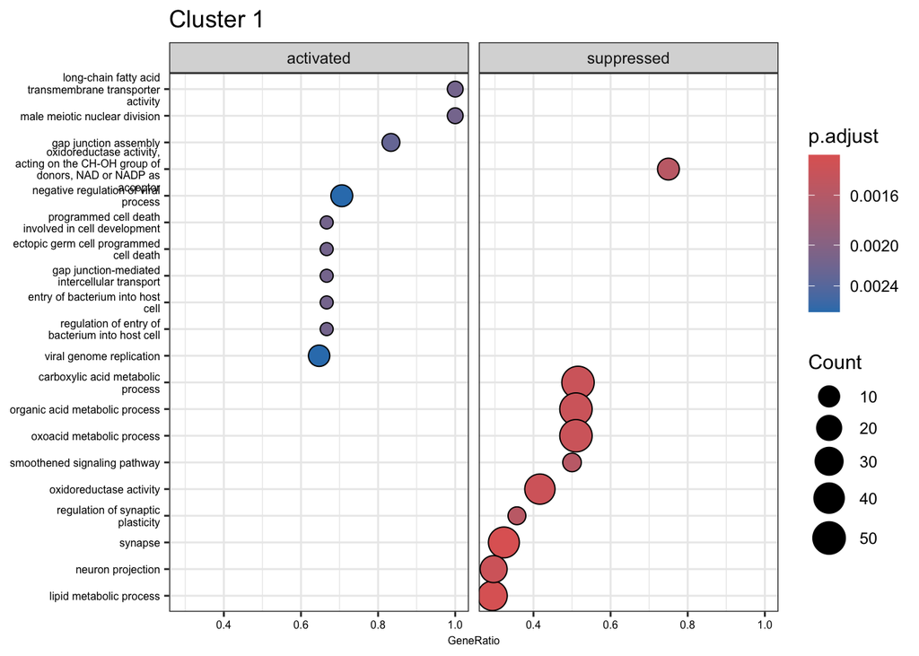

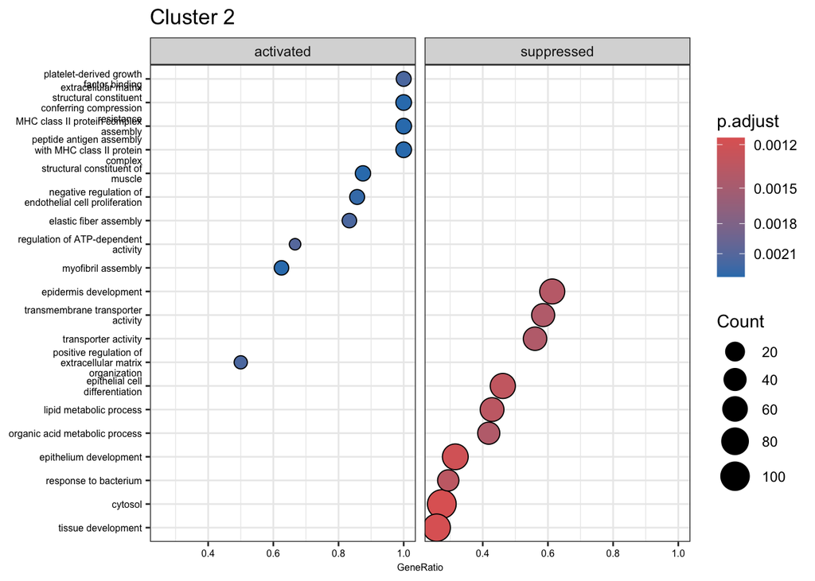

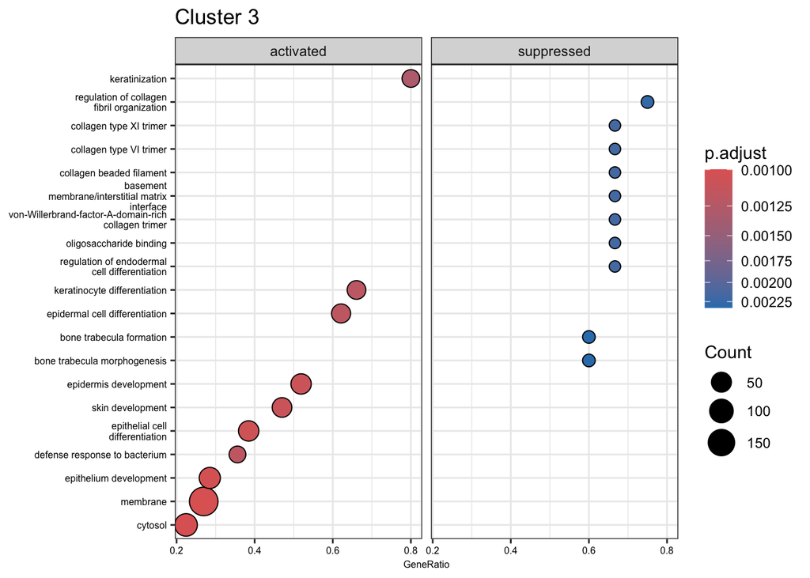

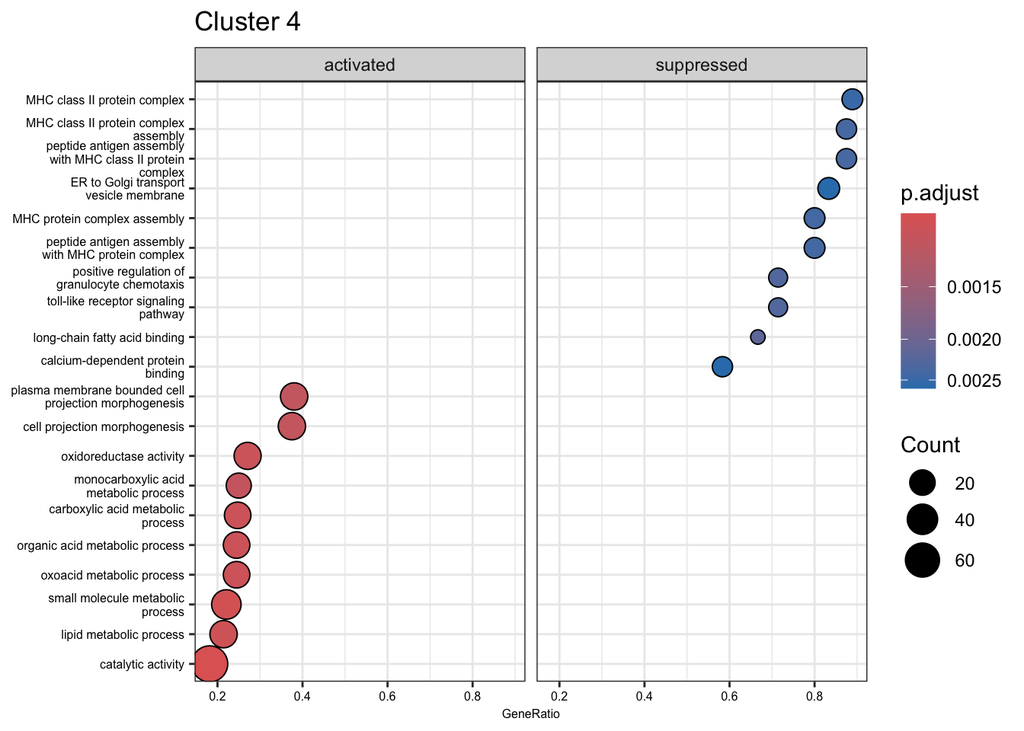

```r
# Dotplots
for (i in 1:4) {
  plot(dotplot(GSEA_res[[i]], showCategory = 10, split = ".sign",
               title = paste0("Cluster ", i), font.size = 6) +
         facet_grid(. ~ .sign))
}
```

# Interpretation of dotplots

The name of the pathways are on the y-axis, while the plots are divided into activated (upregulated) and suppressed (downregulated) categories for each cluster. The count and bubble size represent the number of genes from each specific pathway identified in the dataset. The color of the p.adjust bubbles represents statistical significance, ranging from red (more significant) to blue (less significant).

Cluster 1: The activated pathways in Cluster 1 involve long-chain fatty acid and transmembrane transporter activity, suggesting that these tumors have increased activity in lipid transport and membrane remodeling. The previously observed upregulation of COL17A1 (a structural collagen) and KRT16 (an epithelial filament protein) suggests that these structural keratins work in tandem with membrane transporters to maintain the hyper-proliferative state of squamous cells.

Conversely, the suppressed pathways include lipid metabolic processes, carboxylic acid metabolic processes, and neuron projection/synapse pathways. This suggests a significant shift in the cell composition and metabolic streamlining within the tumor microenvironment of Cluster 1.

Cluster 2: Cluster 2 shows activation of platelet-derived growth, extracellular matrix (ECM) structural constituents, and MHC class II protein complex assembly. This confirms a “remodeling” phenotype, as these tumor cells are producing significant connective tissue and undergoing Epithelial-Mesenchymal Transition (EMT). Furthermore, the upregulation of MHC Class II and peptide antigen assembly suggests an immunologically “hot” tumor microenvironment, characterized by high infiltration of antigen-presenting cells into the tumor stroma.

The suppressed pathways, including tissue, epithelial, and epidermis development, indicate that Cluster 2 samples have lost their squamous identity and shifted toward a more invasive, mesenchymal state.

Cluster 3: The activated pathways in Cluster 3 are dominated by keratinization, epidermal cell differentiation, and skin/epithelium development. The presence of SPRR (small proline-rich proteins) and KRT78 among the top 20 DE genes suggests that these cells are in a state of late-stage squamous differentiation.

The suppressed pathways include the regulation of collagen fibril organization, endodermal cell differentiation, and various collagen trimers. Cluster 3 shows significantly less basement membrane remodeling activity compared to Clusters 1 and 2, suggesting this is a well-differentiated molecular subtype that maintains the structural characteristics of normal esophageal mucosa.

Cluster 4: Cluster 4 is the most metabolically active group, with activated pathways including lipid, organic acid, and monocarboxylic acid metabolic processes, as well as oxidoreductase activity. This aligns with the Q2 findings where ALDH1A1 and UGT1A1—genes responsible for detoxification and metabolic turnover were highly upregulated.

In contrast to the “hot” profile of Cluster 2, Cluster 4 suppresses MHC class II protein complex assembly and Toll-like receptor signaling. This suggests an immunologically “cold” phenotype, as the tumor cells appear to be actively evading immune detection.

In summary, GSEA analysis is able to classify: * Cluster 1 as the proliferative subtype * Cluster 2 as the mesenchymal/infammed subtype * Cluster 3 as the differentiated subtype * Cluster 4 as the metabolic/immune evasive subtype.

4. Repeat the procedure 1-3 above using the consensus clustering algorithm (e.g.,ConsensusClusterPlus R package) and report all the required findings. (5 marks)

Data normalisation prior to ConsensusClusterPlus

```r
mads=apply(escc_data,1,mad)
escc_data2=escc_data[rev(order(mads))[1:1500],]

# Data is normalized by centering around gene median
c_escc_data = sweep(escc_data2,1, apply(escc_data2,1,median))
```

```
## end fraction
```

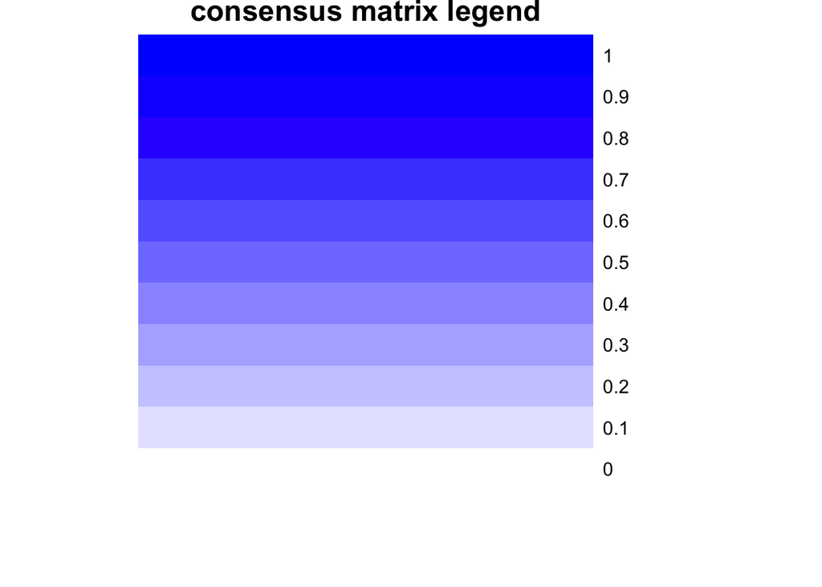

```
## clustered
```

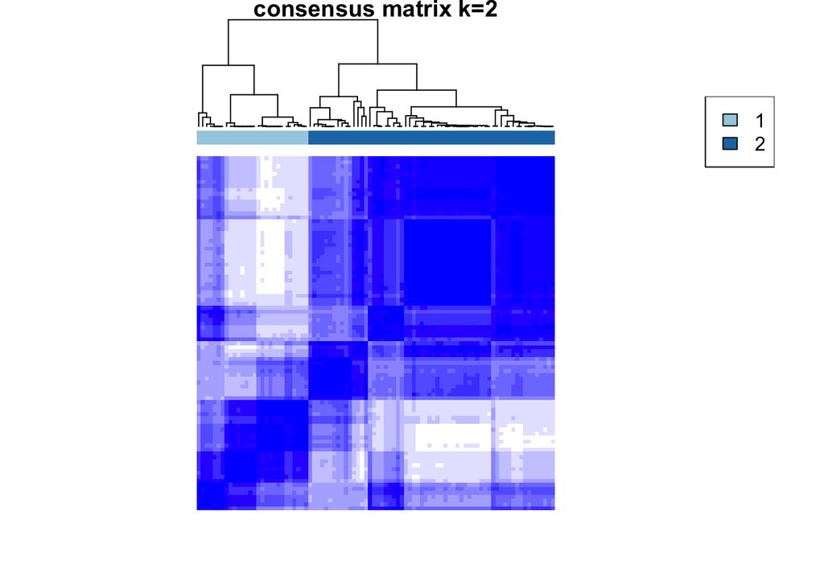

```
## clustered
```

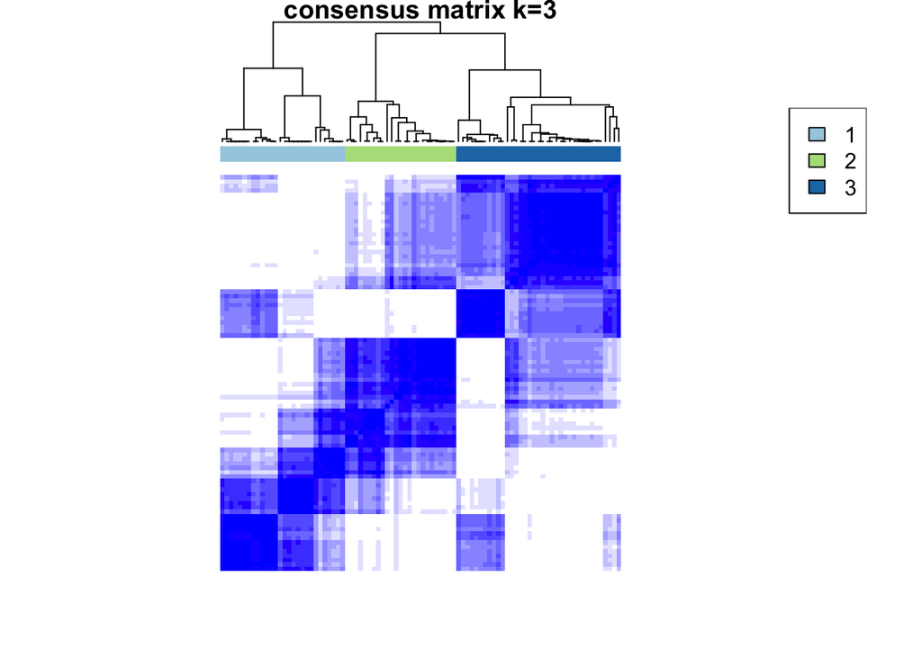

```
## clustered
```

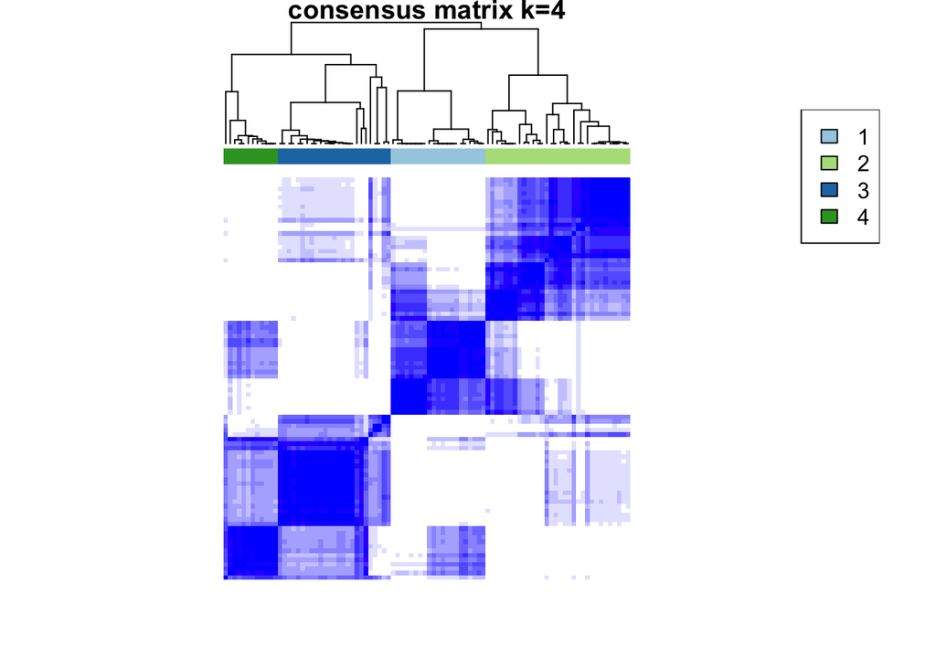

```
## clustered
```

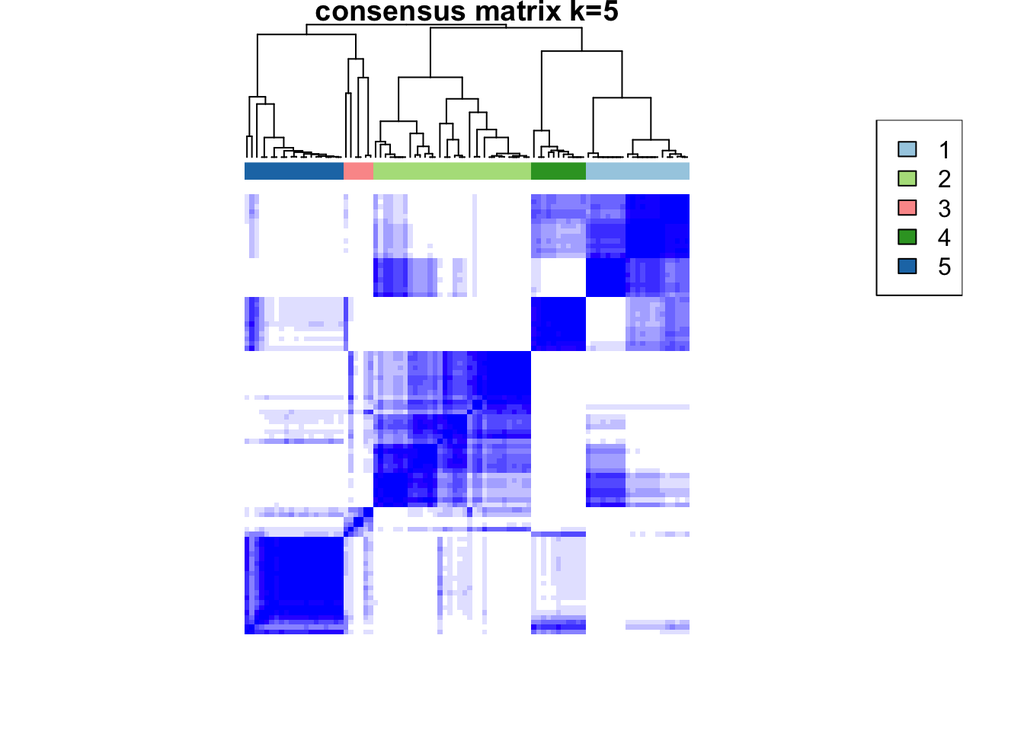

```
## clustered
```

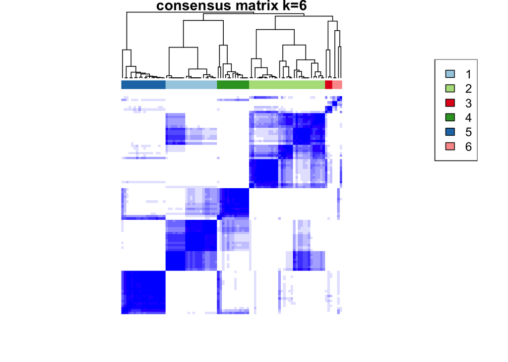

```
## clustered
```

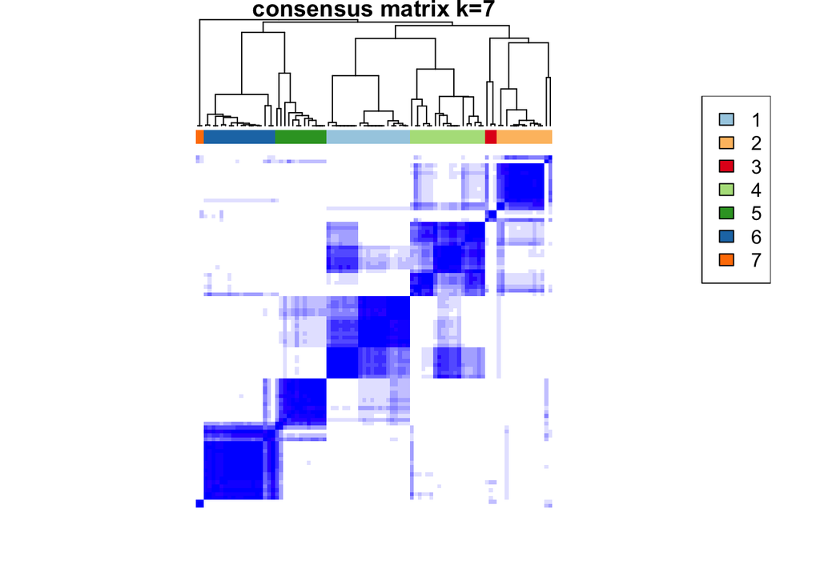

```
## clustered
```

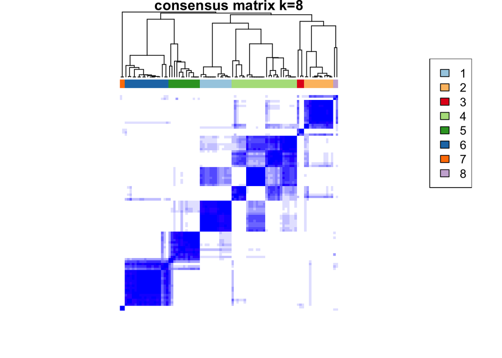

```
## clustered
```

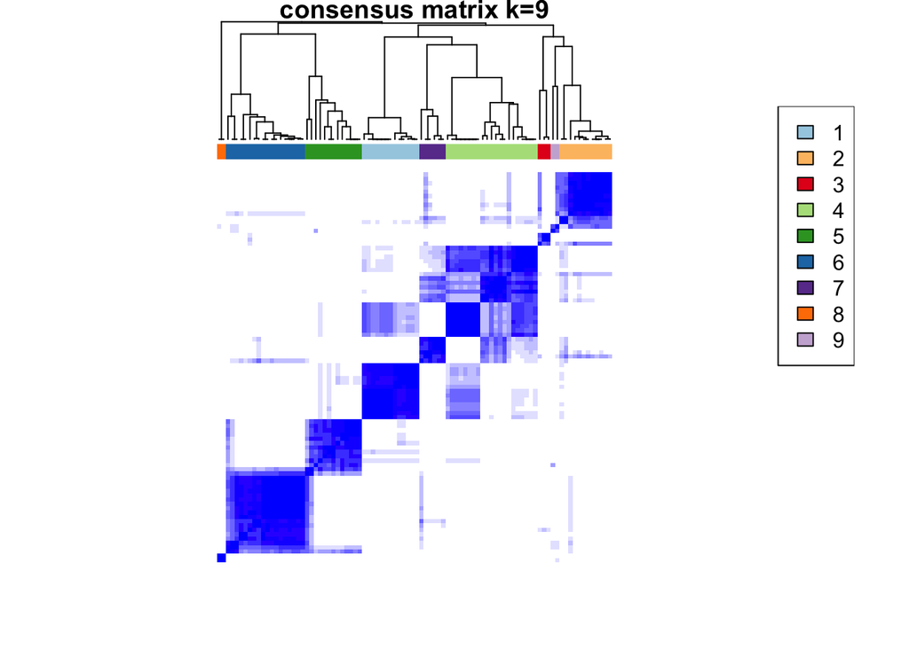

```
## clustered
```

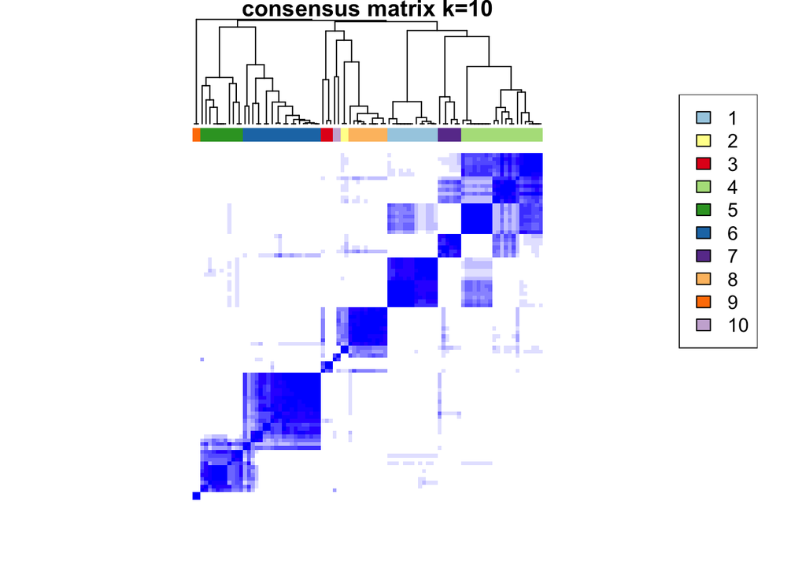

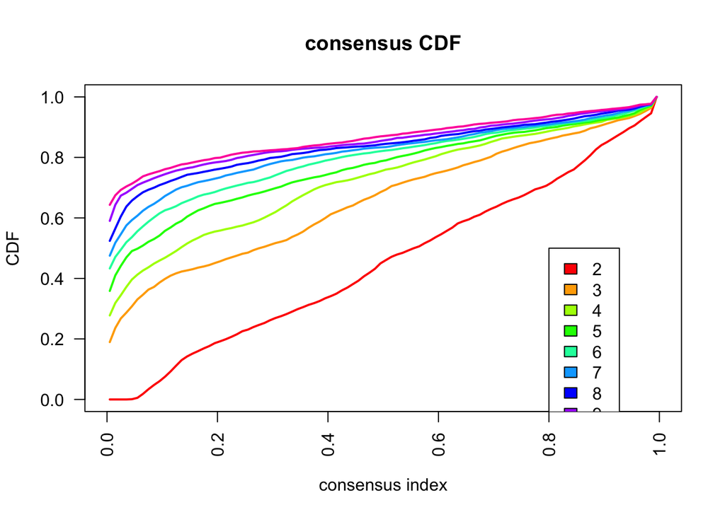

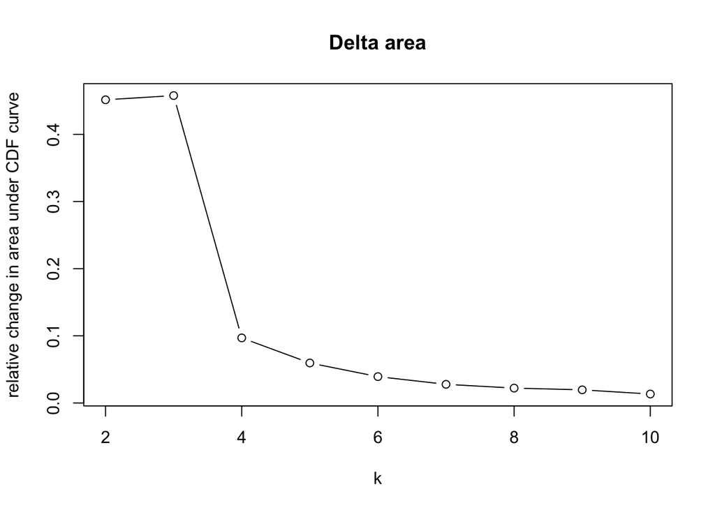

[1 more figures not shown]

```r
library(ConsensusClusterPlus)

consensus_escc = ConsensusClusterPlus(as.matrix(c_escc_data),
                                      maxK=10, # Run 10 clusters
                                      reps=500, # 500 repetitions
                                      pItem=0.8,
                                      pFeature=1,
                                      clusterAlg="hc",
                                      distance="pearson",
                                      seed=420,
                                      plot=NULL)
```

Extract cluster membership from ConsensusClusterPlus object

```r
escc_clusters <- consensus_escc[[4]]$consensusClass
table(escc_clusters)
```

```
## escc_clusters
##  1  2  3  4
## 21 32 25 12
```

Use limma to find significant genes based on differential expression

```r
# Create an empty list to store the results when accessing all 4 clusters
cc_top_20_list <- list()
cc_all_genes_list <- list()

# Create a loop to go through all 4 clusters
for (k in 1:4) {

  cc_group <- factor(ifelse(escc_clusters == k, "ClusterCC", "Rest"))

  # Design matrix
  cc_mod <- model.matrix(~0 + cc_group)
  colnames(cc_mod) <- c("ClusterCC", "Rest")
  rownames(cc_mod) <- colnames(escc_exp)

  # Fit linear model
  cc_fit <- lmFit(escc_exp, cc_mod)
  # Contrast - Subtract the average of Other from the average of ClusterK
  cc_con.matrix <- makeContrasts(ClusterCCvsRest = ClusterCC - Rest, levels = cc_mod)
  # Apply contrast to the linear model
  cc_fit2 <- contrasts.fit(cc_fit, cc_con.matrix)
  cc_fit2 <- eBayes(cc_fit2)

  # Top 20 DE genes
  cc_top20 <- topTable(cc_fit2, adjust = "BH", number = 20, sort.by = "logFC")
  cc_top_20_list[[k]] <- cc_top20

  # All DE genes for GSEA
  cc_all_genes <- topTable(cc_fit2, adjust ="BH", number =Inf)
  cc_all_genes_list <- append(cc_all_genes_list, list(cc_all_genes))

  cat("\n=== Top 20 DE Genes for Consensus Clustering", k, "vs all others ===\n")
  print(cc_top20)
}
```

```
##
## === Top 20 DE Genes for Consensus Clustering 1 vs all others ===
##            logFC  AveExpr         t      P.Value    adj.P.Val         B
## CRCT1   5.159059 3.794712 11.969465 7.728849e-21 1.159327e-17 36.851718
## CNFN    4.302705 6.446069  9.273087 4.839545e-15 1.037045e-12 23.803332
## SPRR2E  4.244486 5.921232  6.896346 5.383453e-10 1.468214e-08 12.452082
## SPRR3   4.041564 6.458253  4.758574 6.773934e-06 5.275503e-05  3.315034
## SPRR2A  3.971070 7.065851  6.667988 1.574612e-09 3.550533e-08 11.407018
## IVL     3.833225 4.408470  9.239583 5.717939e-15 1.072114e-12 23.640173
## SPRR1A  3.827752 7.615238  6.734153 1.155156e-09 2.750371e-08 11.708549
## SPRR2D  3.810929 6.780402  6.771382 9.699602e-10 2.385148e-08 11.878674
## FAM25A  3.803337 3.170199  9.034685 1.584668e-14 2.641113e-12 22.643035
## RHCG    3.742966 5.967664  6.706770 1.313322e-09 3.030742e-08 11.583629
## S100A7  3.652637 8.237717  5.095331 1.707854e-06 1.696543e-05  4.637723
## SBSN    3.622785 5.404141  7.649150 1.457446e-11 7.287230e-10 15.972499
## KLK13   3.584549 3.303560  7.796853 7.104264e-12 3.805856e-10 16.674239
## SPRR1B  3.569392 9.593661  6.829958 7.363456e-10 1.950253e-08 12.147010
## A2ML1   3.560969 4.097919  8.318142 5.512700e-13 4.134525e-11 19.172137
## NCCRP1  3.525595 3.568834  8.813782 4.747661e-14 5.478071e-12 21.569774
## SPINK7  3.468440 2.186291  7.327413 6.896964e-11 2.586361e-09 14.455381
## TGM1    3.445190 4.515202  8.263547 7.214086e-13 5.152919e-11 18.909198
## MAL     3.431627 2.797724  5.546852 2.500381e-07 3.049245e-06  6.490400
## CEACAM6 3.409217 4.147548  7.352980 6.099199e-11 2.345846e-09 14.575309
##
## === Top 20 DE Genes for Consensus Clustering 2 vs all others ===
##              logFC  AveExpr         t      P.Value    adj.P.Val         B
## ALDH3A1   5.099260 4.829094 13.621317 3.317910e-24 1.239028e-21 44.567055
## CES1      4.728371 3.354156  9.176197 8.384236e-15 3.698928e-13 23.202637
## AKR1C3    4.725527 5.257498 13.672671 2.608708e-24 1.239028e-21 44.804053
## CYP4F11   4.434271 3.605440 14.946733 7.380123e-27 1.107018e-23 50.582126
## AKR1B10   4.058981 6.362793 10.979600 1.110821e-18 8.769640e-17 32.015845
## ADH7      4.032874 4.082487  9.983569 1.527685e-16 8.813566e-15 27.154962
## AKR1C2    3.877203 4.913146  9.958182 1.732657e-16 9.625870e-15 27.030687
## GPX2      3.743462 6.591316  8.944036 2.647797e-14 1.045183e-12 22.068425
## LOC344887 3.733361 3.036212 13.574612 4.130094e-24 1.239028e-21 44.351249
## CYP4F3    3.626315 2.428751 12.713144 2.445459e-22 5.240268e-20 40.327146
## NTS       3.551277 3.114868  5.393641 4.909255e-07 6.035969e-06  5.651929
## UGT1A1    3.408843 2.696659 12.268651 2.068433e-21 3.102650e-19 38.220620
## AK126334  3.397435 1.920220 11.971832 8.694433e-21 1.003204e-18 36.803615
## GSTM3     3.359711 3.471543 10.490411 1.241140e-17 8.462317e-16 29.633072
```

[output cut: 37 more lines]

```
## CXCL10   2.680537  4.086510  4.806765 5.623257e-06 2.908581e-04  3.77777499
## CYP4F11 -2.663921  3.605440 -3.748369 3.030436e-04 5.753993e-03  0.08467952
## GBP5     2.656610  2.220638  6.991717 3.517502e-10 5.276253e-07 12.88473117
## GNLY     2.587906  2.593881  6.429170 4.872011e-09 3.654009e-06 10.40408803
## NTS     -2.560521  3.114868 -2.498627 1.415467e-02 7.053823e-02 -3.36024029
## AIM2     2.556990  2.476083  5.739831 1.089874e-07 3.269623e-05  7.47582278
## CCL5     2.459899  3.840012  5.391208 4.949176e-07 8.248627e-05  6.05363465
## ALDH3A1 -2.409292  4.829094 -2.778825 6.555653e-03 4.445064e-02 -2.68742043
## CXCL11   2.338349  2.090631  5.225261 1.000999e-06 1.072499e-04  5.39280174
## MMP28    2.325502  2.534057  5.811552 7.941508e-08 2.978066e-05  7.77370000
## MMP12    2.285852  4.039953  4.478837 2.057409e-05 8.688517e-04  2.56916092
## UCHL1   -2.188695  4.379102 -3.139991 2.241532e-03 2.228307e-02 -1.73201411
## GZMA     2.182734  2.091589  6.050193 2.737200e-08 1.368600e-05  8.77679109
## GPX2    -2.155576  6.591316 -2.813170 5.942573e-03 4.224578e-02 -2.60075712
## KRT14    2.134581 10.444821  2.916115 4.405814e-03 3.406557e-02 -2.33564906
```

Cluster 1 indicates a well-Differentiated subtype due to high expression of genes associated with epidermal differentiation complex, such as CRCT1, CNFN, and the SPRR family (SPRR2E, SPRR3, SPRR2A). This signature correspond to the signature identified in NMF cluster 3.

Cluster 2 indicates a metabolic/detoxification subtype because of high level expression of ALDH3A1 & AKR1C3/AKR1B10 which are the cell’s primary defense against oxidative stress and toxic byproducts of metabolism; CES1 which involved in the hydrolysis of various xenobiotics (foreign substances like drugs or toxins and CYP4F11 which is a Cytochrome P450 enzyme involved in the metabolism of lipids and fatty acids.

Cluster 3 represents an undifferentiated or basal-like subtype because there are significant downregulation of squamous maturation markers, including the Small Proline-Rich Protein (SPRR) family and peptidase inhibitor (PI3). PI3 stops enzymes from breaking down the epithelial structure, hence loss of PI3 lead to tumour microenvironment more susceptible in structural breakdown.

Cluster 4 is identified as the inflamed subtype as shown by upregulation of immune-effector genes (CXCL10, GBP5 & GNLY) indicating a T-cell infiltration and interferon signaling are taking place. This cluster also shows loss of squamous and metabolic markers such as AKR1C2, CES1 and SPRR3 suggesting that the biological profile is shifted entirely toward an immune-active state.

Perform GSEA and report the most upregulated and downregulated pathways for each cluster

```r
# Perform ranked gene lists from limma results
cc_gene_lists <- list()

for (i in 1:4) {
  cc_gene_list <- cc_all_genes_list[[i]]$logFC
  cc_gene_list <- log2(10^cc_gene_list)
  names(cc_gene_list) <- rownames(cc_all_genes_list[[i]])
  cc_gene_list <- sort(cc_gene_list, decreasing = TRUE)
  cc_gene_lists[[i]] <- cc_gene_list
}

# Run GSEA
cc_GSEA_res <- list()

for (i in 1:4) {
  set.seed(420)
  cc_gse <- gseGO(geneList = cc_gene_lists[[i]],
               ont = "ALL",
               keyType = "SYMBOL",
               nPerm = 1000,
               minGSSize = 3,
               maxGSSize = 800,
               pvalueCutoff = 0.05,
               verbose = TRUE,
               OrgDb = "org.Hs.eg.db",
               pAdjustMethod = "none")
  cc_GSEA_res[[i]] <- cc_gse
}
```

[output not shown]

```
## preparing geneSet collections...
```

```
## GSEA analysis...
```

```
## leading edge analysis...
```

```
## done...
```

[output not shown]

```
## preparing geneSet collections...
```

```
## GSEA analysis...
```

```
## leading edge analysis...
```

```
## done...
```

[output not shown]

```
## preparing geneSet collections...
```

```
## GSEA analysis...
```

```
## leading edge analysis...
```

```
## done...
```

[output not shown]

```
## preparing geneSet collections...
```

```
## GSEA analysis...
```

```
## leading edge analysis...
```

```
## done...
```

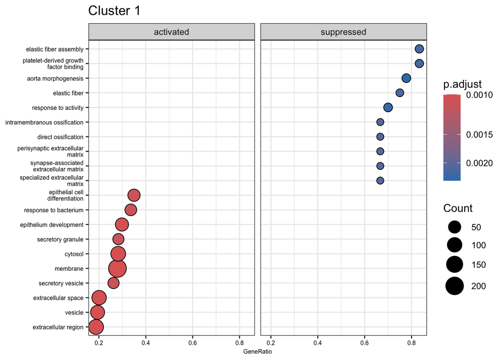

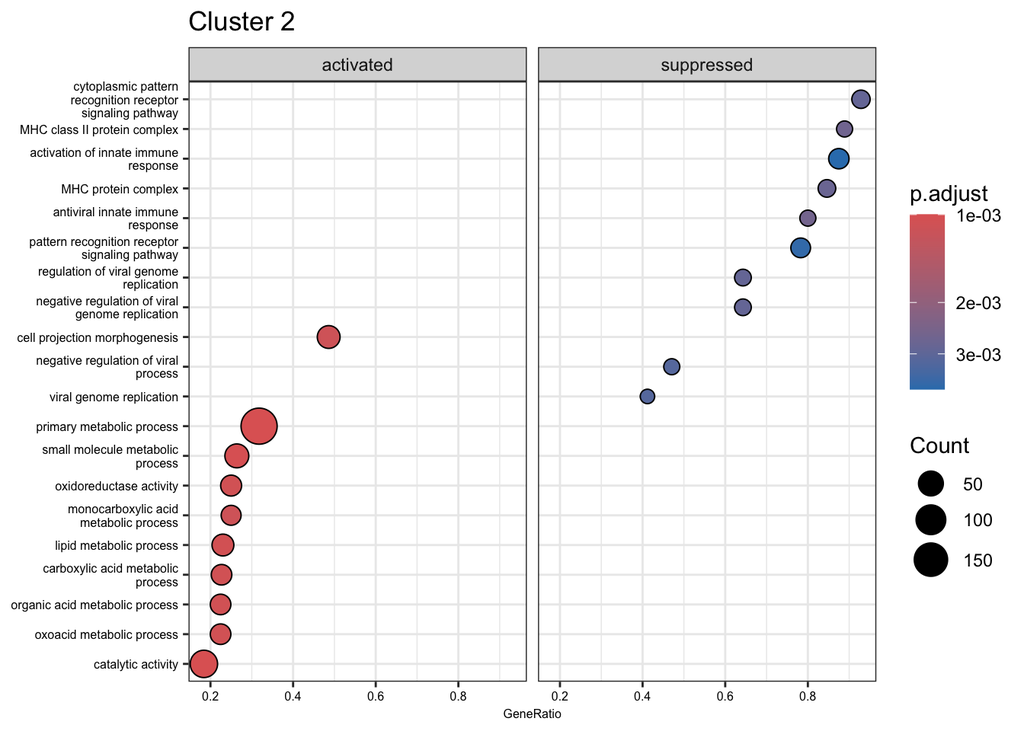

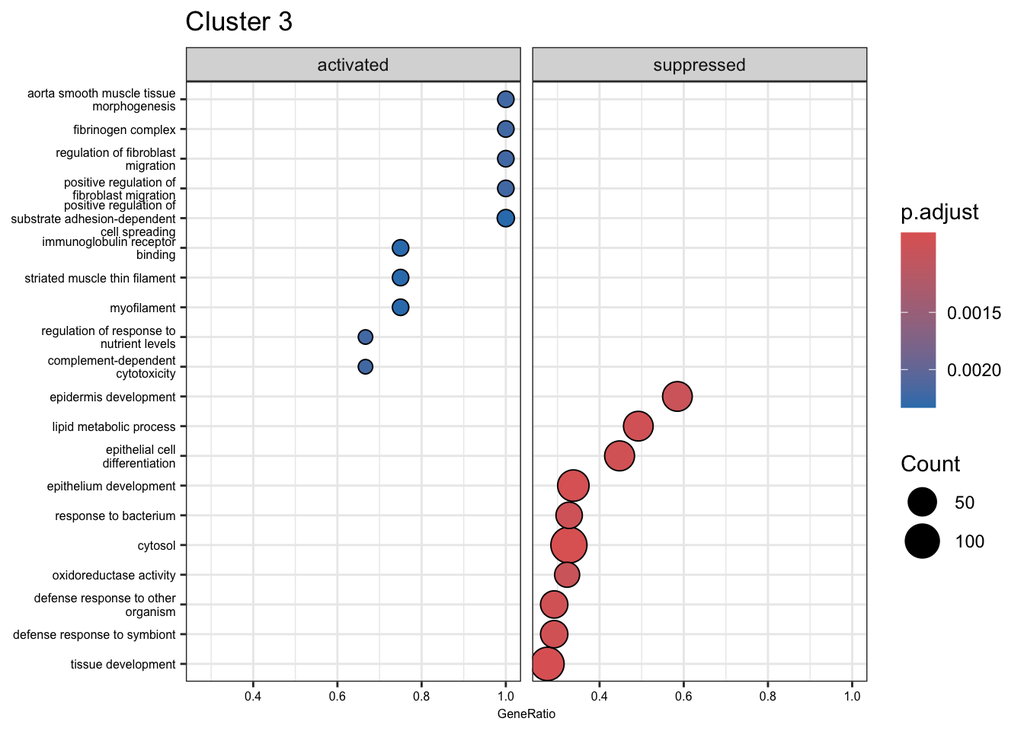

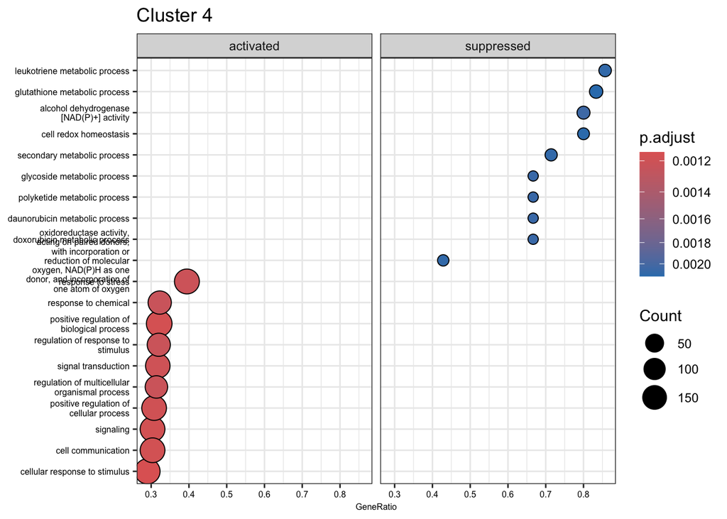

```r
# Dotplots
for (i in 1:4) {
  plot(dotplot(cc_GSEA_res[[i]], showCategory = 10, split = ".sign",
               title = paste0("Cluster ", i), font.size = 6) +
         facet_grid(. ~ .sign))
}
```

# Interpretation of dotplots (ConsensusClusterPlus)

Cluster 1: It shows activation of epithelial cell differentiation, secretory granule, secretory vesicle, cytosol, membrane and extracellular space and region. These suggests tumours retained epithelial function.

The suppressed pathways include 1) structural/extracellular matrix pathways e.g. elastic fiber assembly, elastic fiber, aorta morphogenesis; 2) growth signalling pathway e.g. platelet-derived growth factor binding; 3) tissue remodelling e.g. intramembranous ossification, direct ossification and 4) neural/stromal microenvironment pathways e.g. perisynaptic/synapse-associated extracellular matrix. Suppression of these pathways suggest reduced stromal remodelling.

Cluster 2: It is characterised as metabolically active tumours with immune suppression as it has a strong activation of metabolic pathways e.g. primary metabolic process, small molecule metabolic process, lipid/carboxylic/organic acid metabolic process. It also shows high oxidative activity.

Immune-related pathways are suppressed in cluster 2, particularly MHC class II antigen presentation and innate immune response. This indicates a cold tumour with potential immune evasion.

Cluster 3: It shows strong activation of stromal and mesenchymal pathways e.g. aorta smooth muscle tissue morphogenesis, fibroblast migration and cell adhesion pathway e.g. substrate adhesion-dependent cell spreading. This cluster also show increased immune-related activity such as immunoglobulin receptor binding, complement-dependent cytotoxicity.

Conversely, the suppressed pathways include epidermis development, epithelial cell differentiation, epithelium development, metabolic activity and developmental pathways. This profile suggest a mesenchymal/stromal-enriched tumour subtype potentially reflecting epithelial-to-mesenchymal transition (EMT).

Cluster 4: It shows broad activation of general cell signalling, communication, and stress response pathways e.g. positive regulation of biological process, regulation of response to stimulus, signal transduction, signalling, cell communication.

Detoxification and drug metabolism pathways are strongly suppressed including glutathione metabolism, redox homeostasis, and daunorubicin/doxorubicin metabolism. This suggests these tumours may have reduced drug detoxification capacity, potentially making them more sensitive to chemotherapy.

In summary, GSEA analysis identified these 4 clusters generated by ConsensusClusterPlus as: • Cluster 1 belongs to the Well-Differentiated (Epithelial-Stable) Subtype. • Cluster 2 belongs to the Metabolic / Immune-Cold Subtype • Cluster 3 belongs to the Mesenchymal / Immune-Hot Subtype • Cluster 4 belongs to the Stress-Responsive / Chemo-Sensitive Subtype

5. Finally, compare the clusters and cluster membership between that based on NMF and that from consensus clustering. Are these clusters similar? Are the upregulated and downregulated pathways identified from the two algorithms similar? Comment on the comparison. (4 marks)

Compare NMF and consensus clustering cluster membership

```r
# Create the contingency table
clusters_compare <- table(NMF = cluster_memberships, Consensus = escc_clusters)
print(clusters_compare)
```

```
##    Consensus
## NMF  1  2  3  4
##   1 12  2  7 10
##   2  0  2 18  2
##   3  9  4  0  0
##   4  0 24  0  0
```

# Interpretation of contingency table

Contingency table is like confusion matrix which is the standard method to visualise how samples are distributed between two different clustering results. High scores mean these clusters are equivalent, whereas the scores are split across different clusters mean discordance.

• NMF cluster 4 and Consensus cluster 2 have 24 samples, this is a strong evidence that all these samples that belong to metabolic/immune-cold subtype were grouped together in a same cluster in both algorithms.

• NMF cluster 2 and Consensus cluster 3 have 18 samples belong to mesenchymal/invasive subtype stayed together.

• NMF cluster 3 and Consensus cluster 1 have 9 samples that are well-differentiated cells overlapped. However, some samples from NMF cluster 3 were grouped separately to Consensus cluster 2, suggesting Consensus clustering algorithm detected some metabolic genes in these samples thus grouping them to Consensus cluster 2.

• The most discordance occurred in NMF cluster 1 as the scores are scattered across all Consensus clusters. NMF algorithm grouped this hyperproliferative samples based on a shared keratin profile while Consensus clustering further sub-divide them based on immune microenvironment and stress-response signalling.

# Subtype profile: Well-differentiated

## NMF cluster 3

## Consensus cluster 1

## Number of samples shared: 9

## Consistency: Moderate

# Subtype profile: Metabolic/Immune-Cold

## NMF cluster 4

## Consensus cluster 2

## Number of samples shared: 24

## Consistency: Very High

Both algorithms nearly overlapping perfectly as both identified lipid and organic acid metabolism as the dominant activated pathways and MHC Class II/Immune response as the primary suppressed pathways (Immune-Cold phenotype).

# Subtype profile: Mesenchymal/Invasive

## NMF cluster 2

## Consensus cluster 3

## Number of samples shared: 18

## Consistency: High

Both algorithms capture the EMT. They show a clear lineage swap where epidermis development is suppressed in favor of extracellular matrix structural constituents and fibroblast migration. Both also link this mesenchymal state to an Immune-Hot environment i.e. MHC Class II in NMF and Immunoglobulin binding in Consensus.

# Subtype profile: Aggressive/Stress

## NMF cluster 1

## Consensus cluster 1 and 4

## Number of samples shared: 12 and 10

Both algorithms show active signalling, stress response with NMF focused on the proliferative side while Consensus Clustering focused on the stress and chemosensitive side.

# Conclusion

6. Can you suggest the most appropriate procedure for any unsupervised clustering analysis of a given dataset? How to generate the most robust, reliable clusters? (4 marks)

To generate robust and reliable clusters in any unsupervised analysis that truely represent the biological or physical phenomena, we have to ensure:

1. Data normalisation and transformation - Sequencing raw data should be log-transformed to handle the mean-variance relationships prior to downstream analysis.
2. Feature Selection - Select the top few thousands most variable genes for clustering to ensure the algorithm focuses on the genes that are genuinely different from one to another.
3. Batch correction - Samples come from different batches/sources or processed by different labs could induce biases in the data, apply batch correction/integration so clusters reflect biology rather than technical variation.
4. Determine optimal clusters - Silhouette analysis/Elbow method to measure how similar a sample is to its own cluster compared to others.
5. Use Hierarchical Clustering e.g. Agglomerative clustering that works in a bottom-up manner which is good at identifying small clusters and Divisive clustering that works in a top-down manner which is good at identifying large clusters.
6. Use multiple algorithms to ensure robustness - Compare linear method such as K-means or Consensus Clustering with non-linear method such a NMF.
7. Stability testing - Measure how consistent clusters are across re-sampling, different seeds and parameter choices.
8. Biological Validation - Run downstream analysis such as differential expression between clusters to find gene signatures; functional enrichment such as GSEA to verify if the clusters correspond to known biological functions/pathways.
9. External Validation - Find correlation of survival rate or tumour grade between clusters and clinical data

# References

Qin, Z., Jiang, D., Yu, Z., Li, L., Xu, W., Xu, C., Song, Q., Sun, X., Li, L., Guo, W., Pu, Y., Feng, J., Liu, Y., Wang, H., Wang, L., Qu, Y., He, F., Qin, J., Tan, L., Zhao, J. Y., … Ding, C. (2025). Proteogenomic characterization reveals that lipid droplet formation promotes esophageal squamous cell cancer progression. Science translational medicine, 17(802), eadt0214. https://doi.org/10.1126/scitranslmed.adt0214

Smyth EC, Lagergren J, Fitzgerald RC, Lordick F, Shah MA, Lagergren P, Cunningham D. Oesophageal cancer. Nat Rev Dis Primers. 2017 Jul 27;3:17048. doi: 10.1038/nrdp.2017.48. PMID: 28748917; PMCID: PMC6168059.

Song, A. Y., Mu, L., Dai, X. Y., Wang, L. J., & Huang, L. Q. (2023). Analysis of Significant Genes and Pathways in Esophageal Cancer Based on Gene Expression Omnibus Database. Chinese medical sciences journal = Chung-kuo i hsueh k’o hsueh tsa chih, 38(1), 20–28. https://doi.org/10.24920/004148

Yang, H., Wang, F., Hallemeier, C. L., Lerut, T., & Fu, J. (2024). Oesophageal cancer. Lancet (London, England), 404(10466), 1991–2005. https://doi.org/10.1016/S0140-6736(24)02226-8

Zinovyeva, M. V., Monastyrskaya, G. S., Kopantzev, E. P., Vinogradova, T. V., Kostina, M. B., Sass, A. V., Filyukova, O. B., Uspenskaya, N. Y., Sukhikh, G. T., & Sverdlov, E. D. (2010). Identification of some human genes oppositely regulated during esophageal squamous cell carcinoma formation and human embryonic esophagus development. Diseases of the esophagus : official journal of the International Society for Diseases of the Esophagus, 23(3), 260–270. https://doi.org/10.1111/j.1442-2050.2009.01008.x